# Clasificación general de herramientas, instrumentos y máquinas

En un taller mecánico se utilizan distintos elementos para **medir, marcar, cortar, desbastar, conformar o unir materiales**. Para entenderlos mejor, abajo se agrupan según la **operación principal** que realizan.

## Instrumentos de medición y marcado

Sirven para **medir dimensiones, verificar ángulos, trazar líneas o marcar puntos de referencia**.

### Ejemplos:

- **Escuadra fija de 90°**: comprueba perpendicularidad y planitud.
- **Calibre Vernier (pie de rey)**: mide longitudes, diámetros y profundidades.

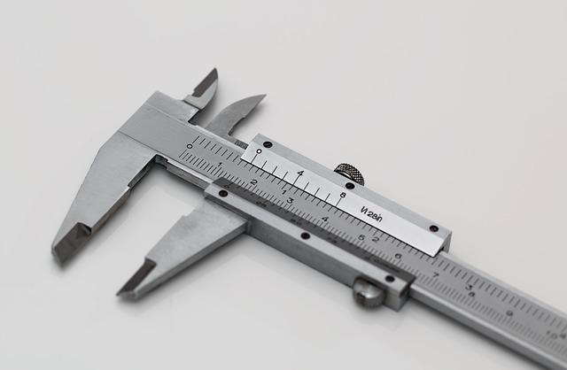

- **Punta de marcar y punta de trazar**: guían cortes o perforaciones.

## Herramientas y máquinas de corte

Sirven para **desprender viruta del material mediante filo**, ya sea manualmente o con ayuda de máquinas. Se incluyen también herramientas que trabajan por **abrasión**, donde los granos abrasivos actúan como micro-filos que arrancan micro-virutas del material.

### Ejemplos:

#### **Manual**

- **Lima**: herramienta que desgasta superficies para dar forma o lograr un ajuste preciso.

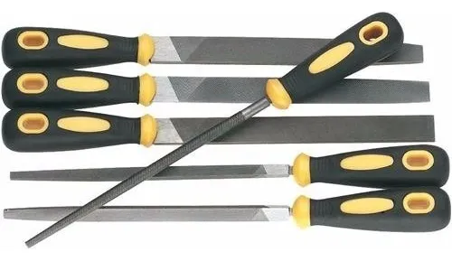

- **Sierra manual**: corta metal, madera o plástico.

[figure not shown]

- **Cortafrío**: es un tipo de cincel utilizado para cortar metal sin necesidad de calentarlo y se emplea junto con un martillo o maza como lo puedes ver [aquí](https://www.youtube.com/shorts/d8TWl__Osls). Su forma puede variar según la tarea.

[figure not shown]

[figure not shown]

- **Lijas**: trabajan por abrasión, eliminando pequeñas virutas del material.

#### **Máquinas**

- **Taladro portátil**: perfora con brocas (mechas).

[figure not shown]

- **Amoladora angular**: corta y desbasta abrasivamente según el disco.

[figure not shown]

- **Amoladora de banco**: desbasta o afila piezas y herramientas mediante abrasión.

[figure not shown]

- **Sierra de cinta**: corta metal usando una cinta sin fin

[figure not shown]

- **Taladro de banco, torno, fresadora**: mecanizan piezas con mayor precisión y potencia.

[figure not shown]

  Taladro de banco

[figure not shown]

  Torno

> **Nota:** las máquinas grandes y fijas, como el torno o la fresadora, se denominan **máquinas-herramienta** en la industria del mecanizado.

## Equipos de unión

Sirven para **unir piezas metálicas mediante calor o presión**.

### Ejemplos

- **Soldadora inverter**: utiliza un arco eléctrico para fundir el metal base y el electrodo revestido, logrando la unión mediante cordón de soldadura.

[figure not shown]

- **Soldadora autógena (oxigas)**: utiliza una mezcla de oxígeno con un gas combustible para fundir el material; el gas más frecuente es el acetileno, aunque también se pueden usar propano, hidrógeno u otros.

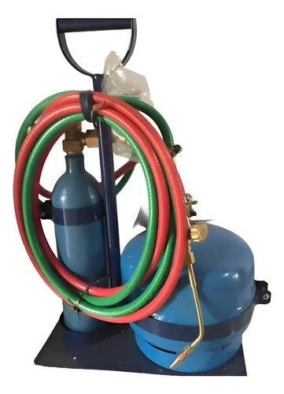

## Máquinas y equipos de conformado

Permiten **dar forma a materiales sin quitar viruta**, por presión o calor.

### Ejemplos:

- Prensas: cortan, doblan o estampan.

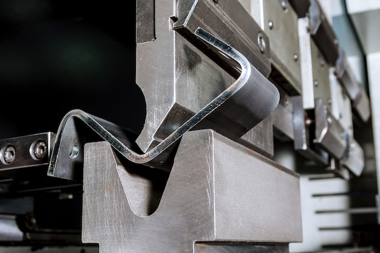

  Prensa para doblado
- Equipos de forja: deforman metales mediante calor y fuerza.

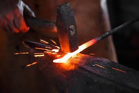

  Forjado de una pieza

## Equipos auxiliares

No cortan ni unen, pero facilitan y aseguran el trabajo.

### Ejemplos:

- Bancos de trabajo

[figure not shown]

- Morsas (para sujetar piezas)

[figure not shown]

[figure not shown]